# Markov Chain - A Practical Example

2021-05-23

## Intro to the problem

In this post I will show a practical example of markov chain.

Let’s try to map the movement of freelancer drivers in Dhaka. We can divide the area of Dhaka into three zones – North Dhaka, Middle Dhaka and South Dhaka.  
So we can find the following probabilities for the movement of a driver:

- Among the North Dhaka’s freelancer drivers, 30% will remain in North Dhaka, 30% will move to Middle Dhaka, while the remaining 40% will go to South Dhaka.
- Of all the drivers in Middle Dhaka, 50% and 30% will move to North Dhaka and South Dhaka, respectively; 20% will remain in Middle Zone.
- In the South Dhaka, drivers have a 40% chance of moving to North Dhaka, 40% chance of staying in the South Dhaka; 20% drivers will move to Middle Dhaka.

Once a driver is in a particular zone, he can either move to the next zone or stay back in the same zone. His movement will be decided **only by his current state** and not by the sequence of past states.

The **state space** in this example includes North Dhaka, Middle Dhaka and South Dhaka. It follows all the properties of Markov Chains because the current state has the power to predict the next stage.

## Transition Probability Matrix

Let’s construct the transition probability matrix -

```r
zone <- c("North","Middle","South")
zoneTPM <- matrix(c(0.3,0.3,0.4,
                    0.5,0.2,0.3,
                    0.4,0.2,0.4),
                  nrow=3, byrow=T, dimnames = list(zone,zone))
```

Hence, the TPM is -

```r
zoneTPM
```

```
#        North Middle South
# North    0.3    0.3   0.4
# Middle   0.5    0.2   0.3
# South    0.4    0.2   0.4
```

The package named `markovchain` can help us in implementing Markov Chains in R.

Install and load the package -

```r
# install.packages("markovchain")
library(markovchain)
```

Now using the function `new()` create a Markov Chain object -

```r
driverzone <- new("markovchain",
                  states = zone,
                  transitionMatrix = zoneTPM,
                  name = "Driver Movement")
driverzone
```

```
# Driver Movement
#  A  3 - dimensional discrete Markov Chain defined by the following states:
#  North, Middle, South
#  The transition matrix  (by rows)  is defined as follows:
#        North Middle South
# North    0.3    0.3   0.4
# Middle   0.5    0.2   0.3
# South    0.4    0.2   0.4
```

## Transition Diagram

To plot the above transition matrix we can use R package, `diagram`. The package has a function called `plotmat()` that can help us in plotting a state space diagram of the transition matrix in an easy-to-understand manner.

Install and load the package -

```r
# install.packages("diagram")
library(diagram)
```

Code for plotting the transition probability diagram -

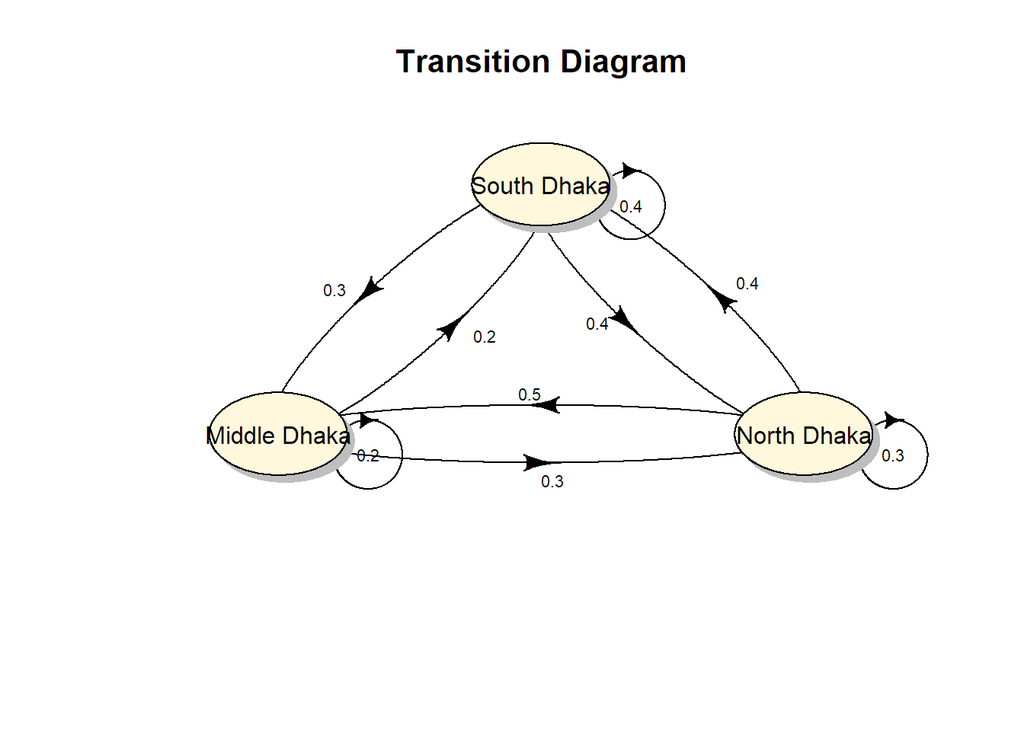

```r
plotmat(A = zoneTPM,
        box.type = "circle",          # shape of box
        box.lwd = 1,                  # border density of box
        relsize = 0.9,                # scaling factor for size of graph
        cex.txt = 0.7,                # size of probabilities
        lwd = 1,                      # border density of state to state arrows
        lcol = "black",
        box.col = "cornsilk1",
        box.size = 0.1,               # size of box
        box.prop = 0.6,               # height to width ratio of box
        arr.length = 0.5, arr.width = 0.2,
        self.cex = 0.5,                          # size of self probability box
        self.shifty = -0.03, self.shiftx = 0.13, # location of self prob. box
        name = c("North Dhaka","Middle Dhaka","South Dhaka"),  # Optional
        main = "Transition Diagram",
        cex.main = 1.3                # relative size of main title
        )
```

The above Markov Chain can be used to answer some of the future state questions.

## Questions

**Assuming that a driver is currently in the North Zone, what is the probability that the driver will again be in the North Zone after two trips?**

**Answer:**

Using code:

Using the markov chain object created earlier using the function `new()` -

```r
driverzone^2
```

```
# Driver Movement^2
#  A  3 - dimensional discrete Markov Chain defined by the following states:
#  North, Middle, South
#  The transition matrix  (by rows)  is defined as follows:
#        North Middle South
# North   0.40   0.23  0.37
# Middle  0.37   0.25  0.38
# South   0.38   0.24  0.38
```

This gives us the direct probability of a driver coming back to the North Zone after two trips.

```r
driverzone^3
```

```
# Driver Movement^3
#  A  3 - dimensional discrete Markov Chain defined by the following states:
#  North, Middle, South
#  The transition matrix  (by rows)  is defined as follows:
#        North Middle South
# North  0.383  0.240 0.377
# Middle 0.388  0.237 0.375
# South  0.386  0.238 0.376
```

However if we increase n (No. of trips) the predictive power tends to go down, where the Markov Chain reaches an equilibrium called `stationary state`. In the above case, after 9 trips the state becomes stationary -

```r
driverzone^9
```

```
# Driver Movement^9
#  A  3 - dimensional discrete Markov Chain defined by the following states:
#  North, Middle, South
#  The transition matrix  (by rows)  is defined as follows:
#            North    Middle     South
# North  0.3853211 0.2385321 0.3761468
# Middle 0.3853211 0.2385321 0.3761468
# South  0.3853211 0.2385321 0.3761468
```

## Steady State

```r
steadyStates(driverzone)
```

```
#          North    Middle     South
# [1,] 0.3853211 0.2385321 0.3761468
```

So we can say that, in the stationary state, a driver has a probability of 0.385 of ending up in the North Dhaka.

**If there were 100 drivers in all and each completes 9 trips in a day, how many of them will end up in the Middle Dhaka?**

```r
steadyStates(driverzone)*100
```

```
#         North   Middle    South
# [1,] 38.53211 23.85321 37.61468
```

So, around 38 drivers will end up in North Dhaka, 24 in the Middle Dhaka and 37 in the South Dhaka.

## Reference

1. [AN INTRODUCTION TO MARKOV CHAINS USING R](https://dataconomy.com/2018/03/an-introduction-to-markov-chains-using-r/) by [CHAITANYA SAGAR](https://www.linkedin.com/in/chaitanyasagar/)